# Assignment Sentiment Analysis

# Step 2: Extension Using NewsAPI (Full News Articles)

This section extends the analysis to real-world news articles collected using NewsAPI. This implementation uses full articles rather than headlines only.

The analysis is extended using multiple sentiment lexicons including Bing, NRC, AFINN, and Loughran–McDonald (finance/news-oriented lexicon).

### Collect News Articles from NewsAPI

This step retrieves full news articles for multiple categories using the NewsAPI /v2/everything endpoint.

```r
library(httr)
library(jsonlite)
library(dplyr)
library(purrr)
api_key <- Sys.getenv("NEWS_API_KEY")

categories <- c("politics", "technology", "business", "sports")

get_news <- function(query) {
  url <- paste0(
    "https://newsapi.org/v2/everything?q=",
    query,
    "&pageSize=100&language=en&apiKey=",
    api_key
  )

  res <- GET(url)
  data <- fromJSON(content(res, "text", encoding = "UTF-8"))

  tibble(
    category = query,
    title = data$articles$title,
    description = data$articles$description,
    content = data$articles$content
  )
}

news_df <- map_dfr(categories, get_news)

head(news_df)
```

```
# A tibble: 6 × 4
  category title                                             description content
  <chr>    <chr>                                             <chr>       <chr>
1 politics RFK Jr. Will Take on Joe Rogan for Podcaster Sup… "\"This is… "Rober…
2 politics OpenAI made economic proposals — here’s what DC … "Happy cea… "<ul><…
3 politics Messy and unpredictable: What I learned from ele… "BBC Radio… "It ha…
4 politics Get ready for a wave of TBPN clones after its bl… "TBPN has … "TBPN …
5 politics Kalshi says it will crack down on politicians an… "Kalshi sa… "Kalsh…
6 politics Trump fires attorney general Pam Bondi.           "Taking a … "<ul><…
```

### Create Full Article Text Field

This step combines title, description, and content into a single analysis-ready text field.

```r
news_df <- news_df %>%
  group_by(category) %>%
  mutate(
    article_id = row_number(),
    text = paste(title, description, content, sep = " ")
  ) %>%
  ungroup()
```

### Tokenization

Full news articles are converted into tidy word-level format and stop words are removed.

```r
tidy_news <- news_df %>%
  unnest_tokens(word, text) %>%
  anti_join(stop_words)
head(tidy_news)
```

```
# A tibble: 6 × 6
  category title                            description content article_id word
  <chr>    <chr>                            <chr>       <chr>        <int> <chr>
1 politics RFK Jr. Will Take on Joe Rogan … "\"This is… Robert…          1 rfk
2 politics RFK Jr. Will Take on Joe Rogan … "\"This is… Robert…          1 jr
3 politics RFK Jr. Will Take on Joe Rogan … "\"This is… Robert…          1 joe
4 politics RFK Jr. Will Take on Joe Rogan … "\"This is… Robert…          1 rogan
5 politics RFK Jr. Will Take on Joe Rogan … "\"This is… Robert…          1 podc…
6 politics RFK Jr. Will Take on Joe Rogan … "\"This is… Robert…          1 supr…
```

### Bing Sentiment by Article

This step calculates sentiment per article using Bing lexicon and aggregates sentiment scores.

```r
bing_sentiment <- tidy_news %>%
  inner_join(get_sentiments("bing")) %>%
  inner_join(news_df %>% select(category, article_id)) %>%

  # count sentiment words per article
  group_by(category, article_id, sentiment) %>%
  summarise(n = n(), .groups = "drop") %>%

  # create chapter-like chunks within EACH category
  mutate(index = article_id %/% 1) %>%

  # aggregate within category + chunk
  group_by(category, index, sentiment) %>%
  summarise(n = sum(n), .groups = "drop") %>%

  # reshape sentiment columns
  pivot_wider(names_from = sentiment,
              values_from = n,
              values_fill = 0) %>%

  # net sentiment
  mutate(sentiment = positive - negative)
```

### Sentiment Visualization (News Articles)

This plot shows sentiment variation across different news categories.

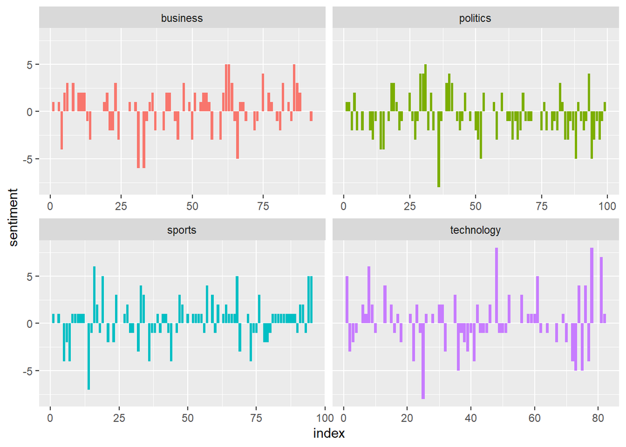

```r
library(ggplot2)

ggplot(bing_sentiment, aes(x = index, y = sentiment, fill = category)) +
  geom_col(show.legend = FALSE) +
  facet_wrap(~category, scales = "free_x", ncol = 2)
```

### Bag-of-Words Sentiment Exploration

This section identifies the most frequent sentiment-contributing words in political news articles using Bing lexicon.

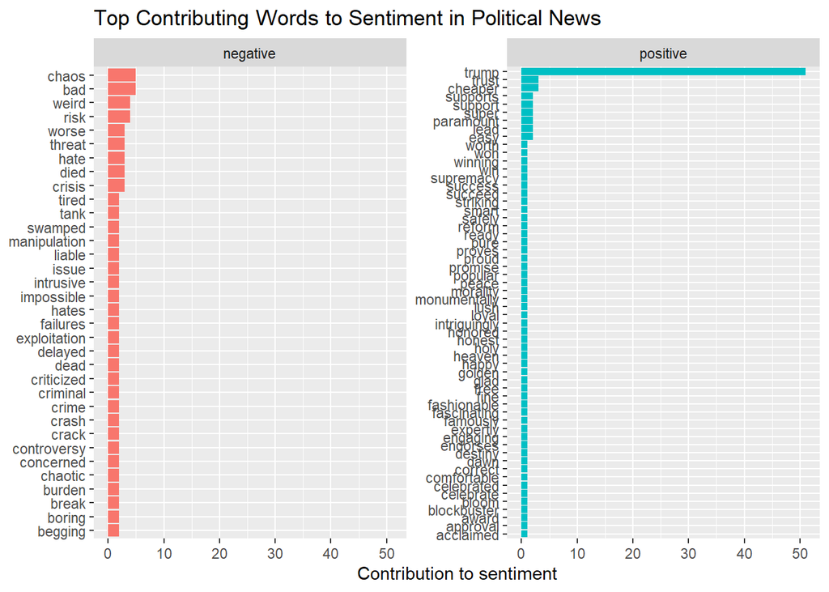

```r
bing_word_counts_news <- tidy_news %>%
  filter(category == "politics") %>%   # focus on politics only
  inner_join(get_sentiments("bing")) %>%
  count(word, sentiment, sort = TRUE) %>%
  ungroup()
bing_word_counts_news %>%
  group_by(sentiment) %>%
  slice_max(n, n = 10) %>%
  ungroup() %>%
  mutate(word = reorder(word, n)) %>%
  ggplot(aes(x = n, y = word, fill = sentiment)) +
  geom_col(show.legend = FALSE) +
  facet_wrap(~sentiment, scales = "free_y") +
  labs(
    title = "Top Contributing Words to Sentiment in Political News",
    x = "Contribution to sentiment",
    y = NULL
  )
```

### Stop Words and Cleaning Effect

This section improves sentiment accuracy by removing misleading or non-informative words using a custom stop word list.

```r
library(tibble)

custom_stop_words <- bind_rows(
  tibble(word = c("trump"), lexicon = "custom"),
  stop_words
)

politics_news_clean <- tidy_news %>%
  filter(category == "politics") %>%
  anti_join(custom_stop_words, by = "word")
```

### Lexicon Comparison (AFINN, Bing, NRC, Loughran)

This section compares multiple sentiment lexicons applied to political news articles only, enabling a direct evaluation of sentiment methodology differences.

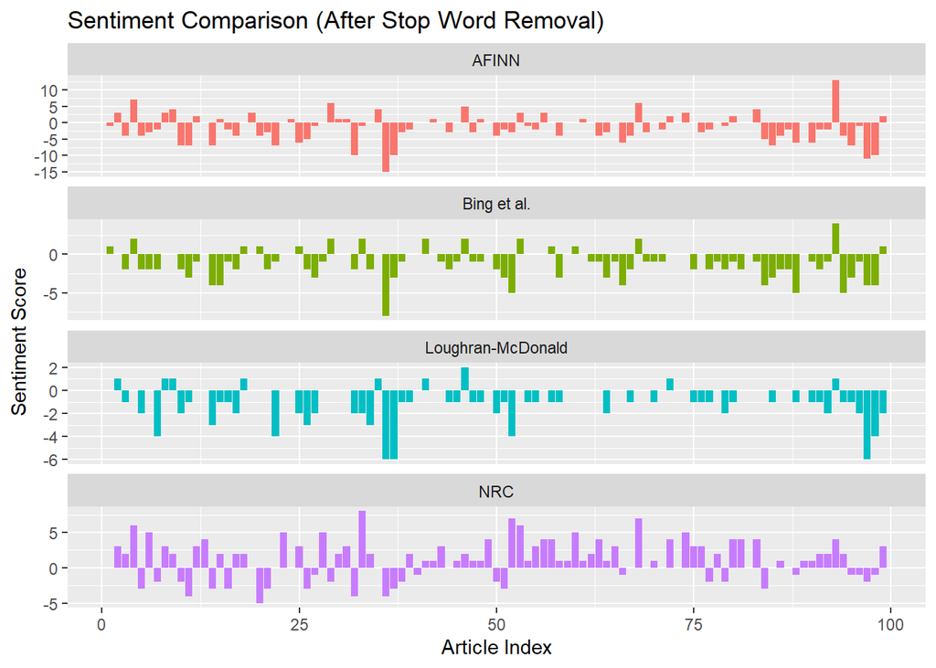

```r
afinn_clean <- politics_news_clean %>%
  inner_join(get_sentiments("afinn")) %>%
  group_by(index = article_id %/% 1) %>%
  summarise(sentiment = sum(value), .groups = "drop") %>%
  mutate(method = "AFINN")
bing_nrc_clean <- bind_rows(

  politics_news_clean %>%
    inner_join(get_sentiments("bing")) %>%
    mutate(method = "Bing et al."),

  politics_news_clean %>%
    inner_join(
      get_sentiments("nrc") %>%
        filter(sentiment %in% c("positive", "negative"))
    ) %>%
    mutate(method = "NRC")

) %>%
  count(method, index = article_id %/% 1, sentiment) %>%
  pivot_wider(
    names_from = sentiment,
    values_from = n,
    values_fill = 0
  ) %>%
  mutate(sentiment = positive - negative)
loughran_clean <- politics_news_clean %>%
  inner_join(
    get_sentiments("loughran") %>%
      filter(sentiment %in% c("positive", "negative"))
  ) %>%
  count(index = article_id %/% 1, sentiment) %>%
  pivot_wider(
    names_from = sentiment,
    values_from = n,
    values_fill = 0
  ) %>%
  mutate(
    sentiment = positive - negative,
    method = "Loughran-McDonald"
  )
bind_rows(
  afinn_clean,
  bing_nrc_clean,
  loughran_clean
) %>%
  ggplot(aes(x = index, y = sentiment, fill = method)) +
  geom_col(show.legend = FALSE) +
  facet_wrap(~method, ncol = 1, scales = "free_y") +
  labs(
    title = "Sentiment Comparison (After Stop Word Removal)",
    x = "Article Index",
    y = "Sentiment Score"
  )
```

# Conclusion

This analysis reproduced the sentiment analysis workflow from Chapter 2 of Text Mining with R: A Tidy Approach and extended it using a corpus of full news articles. Compared to the original example using Jane Austen’s novels, the results differ noticeably. The literary text produced smoother and more consistent sentiment patterns due to its structured narrative and stable language. In contrast, the news article corpus resulted in more volatile and less consistent sentiment scores, reflecting the mixed tone, factual reporting style, and domain-specific vocabulary of real-world news.

Differences across lexicons were also more pronounced in the news data. The AFINN lexicon showed greater variation due to its numeric scoring system, while Bing and NRC produced sharper positive/negative swings. The Loughran–McDonald lexicon further diverged by emphasizing domain-specific negative terms common in formal or economic contexts. Additionally, applying custom stop word removal changed the sentiment distribution, highlighting the importance of preprocessing choices.

Overall, the extended analysis demonstrates that sentiment results depend heavily on both the type of text corpus and the choice of lexicon, with real-world data requiring more careful interpretation than structured literary text.

# References

1. Silge, J., Robinson, D., & Robinson, D. (2017). Text mining with R: A tidy approach (p. 194). Boston (MA): O’reilly.
2. Hu, M., & Liu, B. (2004). Mining and summarizing customer reviews. In Proceedings of the tenth ACM SIGKDD international conference on Knowledge discovery and data mining (pp. 168-177).
3. Nielsen, F. Å. (2011). A new ANEW: Evaluation of a word list for sentiment analysis in microblogs. arXiv preprint arXiv:1103.2903.
4. Mohammad, S. M., & Turney, P. D. (2013). Crowdsourcing a word–emotion association lexicon. Computational intelligence, 29(3), 436-465.
5. Loughran, T., & McDonald, B. (2011). When is a liability not a liability? Textual analysis, dictionaries, and 10‐Ks. The Journal of finance, 66(1), 35-65.
6. OpenAI. (2026, April 19). ChatGPT conversation with K. M. Qaiduzzaman on Sentiment Analysis Extension in R. Retrieved April 19, 2026, from https://chat.openai.com/